# ME111 - Laboratório de Estatística

## Testes Chi-Quadrado: Aderência e Independência

## Introdução

Muitas vezes, a informação da amostra coletada tem a estrutura de dados categorizados, ou seja, cada membro da população pode assumir um entre \(k\) valores de uma ou mais características estudadas.

Dessa forma, o conjunto de dados consiste em frequências de contagens para essas categorias.

Temos os seguintes testes para dados agrupados em categorias múltiplas através:

- Teste de Aderência (ou Bondade de Ajuste)
- Teste de Independência
- Teste de Homogeneidade

## Introdução

**Teste de Aderência:** considere uma população na qual cada membro assume qualquer um de \(k\) possíveis valores. Iremos verificar quão adequado uma amostra obtida dessa população se ajusta a um modelo de probabilidade proposto.

**Teste de Independência:** considere uma população na qual cada membro é classificado de acordo com duas características distintas. Com os dados de uma amostra dessa população, iremos verificar se essas duas características podem ser consideradas independentes.

Duas características serão independentes se a classificação de um membro da população de acordo com uma característica não interfere na probabilidade de classificação em relação à segunda característica desse mesmo membro.

Na aula de hoje iremos focar em Testes de Aderência.

## Exemplo: Cores de Geladeira

Uma determinada marca de geladeira é vendida em cinco cores diferentes e uma pesquisa de mercado quer avaliar a popularidade das várias cores.

As frequências abaixo são observadas para uma amostra de 300 vendas feitas num semestre.

Suponha que seja de interesse testar a hipótese das cinco cores serem igualmente populares.

Vendas das cinco cores das geladeiras da marca W

| Cor | marrom | creme | vermelho | azul | branco | total |
| --- | --- | --- | --- | --- | --- | --- |
| Frequência | 88 | 65 | 52 | 40 | 55 | 300 |

## Modelo Multinomial

## Distribuição Multinomial

Para acomodar dados como no Exemplo 1, precisamos estender o modelo Bernoulli de forma que os resultados possam ser classificados em mais de duas categorias. Esse modelo é chamado de **distribuição multinomial**.

**Modelo Multinomial**

1. O resultado de cada amostra pode ser classificado em uma de \(k\) respostas denotadas por \(1, 2,\ldots, k\).
2. A probabilidade da amostra assumir o valor \(i\) é \(p_{i}\), \(i=1, 2, \ldots,k\), com \[\sum_{i=1}^{k}p_{i}=1\]
3. As observações são independentes.

## Distribuição Multinomial

Considere uma amostra de uma população que consiste de elementos em diversas categorias, por exemplo, \(k\) valores possíveis.

Denotaremos por \(n_1, n_2, \ldots , n_k\), com \(\sum_{i=1}^{k}n_{i}=n\) as frequências e \(p_1, p_2, \ldots , p_k\) as probabilidades.

A distribuição conjunta de \(n_1, n_2, \ldots , n_k\) é chamada de distribuição multinomial e tem função de probabilidade dada por:

\[f(n_1, n_2, \ldots , n_k)=\frac{n!}{n_1! \ldots n_k!}p_1^{n_1}p_2^{n_2} \ldots p_k^{n_k}\]

em que \(\displaystyle \sum_{i=1}^{k}n_{i}=n\) e com \(\displaystyle \sum_{i=1}^{k}p_{i}=1\).

## Distribuição Multinomial

Se designarmos a componente \(n_1\) como "sucesso" e juntarmos as demais numa mesma que designamos "fracasso", a variável aleatória \(n_1\) é o número de sucessos em \(n\) ensaios de Bernoulli, ou seja, \(n_1 \sim Bin(n,p_1)\).

Portanto, \(\mathbb E(n_1)=np_1\), \(Var(n_1)=np_1(1-p_1)\).

Analogamente aplicando o mesmo argumento a cada \(n_i\) temos: \[\mathbb E(n_i)=np_i \quad \mbox{e} \quad Var(n_i)=np_i(1-p_i)\]

Iremos usar o valor esperado de \(n_i\) nos testes que veremos a seguir.

## Teste de Aderência

## Teste de Aderência

**Objetivo:** Testar quão adequado é assumir um modelo probabilístico para descrever um determinado conjunto de dados.

**Exemplo**: Vocês já devem ter visto em alguma aula de Biologia o seguinte:

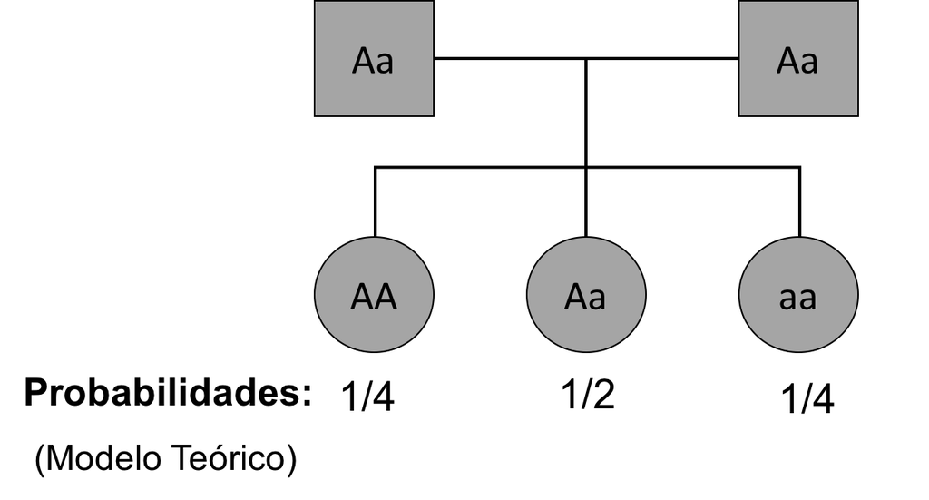

3 genótipos (categorias): AA, Aa e aa

## Teste de Aderência

Em uma certa população, 100 descendentes foram estudados, fornecendo a tabela a seguir:

| Genótipo | AA | Aa | aa | Total |
| --- | --- | --- | --- | --- |
| Frequência Observada | 26 | 45 | 29 | 100 |

\[ \]

**Objetivo:** Verificar se o modelo genético proposto (Equilíbrio de Hardy-Weinberg) é adequado para essa população.

## Teste de Aderência

Se o modelo teórico for adequado, a freqüência esperada de descendentes para o genótipo AA, dentre os 100 indivíduos, pode ser calculada por: \[100 \times P(AA) = 100 \times \frac{1}{4} = 25\]

Da mesma forma para o genótipo Aa: \[100 \times P(Aa) = 100 \times \frac{1}{2} = 50\]

E para o genótipo aa: \[100 \times P(aa) = 100 \times \frac{1}{4} = 25\]

## Teste de Aderência

Podemos expandir a tabela de frequências dada anteriormente com as frequências esperadas sob o modelo teórico:

| Genótipo | AA | Aa | aa | Total |
| --- | --- | --- | --- | --- |
| Frequência Observada | 26 | 45 | 29 | 100 |
| Frequência Esperada | 25 | 50 | 25 | 100 |

**Pergunta:** Podemos afirmar que os valores observados estão suficientemente próximos dos valores esperados, de tal forma que o modelo genético teórico é adequado a esta população?

O procedimento que responde esse tipo de pergunta é chamado de **teste de bondade de ajuste** ou **teste de aderência**.

## Teste de Aderência - Procedimento

Considere uma tabela de freqüências, com \(k \geq 2\) categorias de resultados:

| Categorias | 1 | 2 | … | k | Total |
| --- | --- | --- | --- | --- | --- |
| Frequência Observada | \(O_1\) | \(O_2\) | … | \(O_k\) | \(n\) |

Sendo \(O_i\) o total de indivíduos observados na categoria \(i\), \(i=1,2, \ldots, k\).

Seja \(p_i\) a probabilidade associada à categoria \(i\), \(i=1,2, \ldots, k\).

O objetivo do teste de aderência é testar as hipóteses

\[\begin{aligned} H_0: & p_1=p_{01}, \ldots , p_k= p_{0k} \\ H_a: & \mbox{existe pelo menos uma diferença} \end{aligned} \] sendo \(p_{0i}\) a probabilidade da categoria \(i\) sob o modelo teórico e \(\sum_{i=1}^k p_{0i} =1\)

## Teste de Aderência - Procedimento

Se \(E_i\) é o total de indivíduos esperados na categoria \(i\), quando a hipótese nula \(H_0\) é verdadeira, então:

\[E_i = n\times p_{0i}, \quad i=1,2, \ldots, k.\]

Então, expandindo a tabela de freqüências original, temos

| Categorias | 1 | 2 | … | k | Total |
| --- | --- | --- | --- | --- | --- |
| Frequência Observada | \(O_1\) | \(O_2\) | … | \(O_k\) | \(n\) |
| Frequência Esperada | \(E_1\) | \(E_2\) | … | \(E_k\) | \(n\) |

## Teste de Aderência - Procedimento

Para quantificar quão distante os frequências observadas estão das frequências esperadas, usamos a seguinte estatística:

**Estatística do Teste**: \[\chi^2=\sum_{i=1}^k \frac{(O_i-E_i)^2}{E_i} = \sum^{k}_{i=1}\frac{(n_i-np_{0i})^2}{np_{0i}}\]

Se \(H_0\) é verdadeira: \(\chi^2 \sim \chi^2_{k-1}\)

Em outras palavras, se \(H_0\) é verdadeira, a v.a. \(\chi^2\) segue uma distribuição aproximadamente Qui-quadrado com \(k-1\) graus de liberdade.

**Condição**: Este resultado é válido para \(n\) grande e para frequências esperadas maiores ou iguais a 5.

## Teste de Aderência - Procedimento

Calcular o **valor-de-p** ou encontrar o **valor crítico**.

**Valor-de-p**: \(P(\chi^2_{k-1} \geq \chi^2_{obs}),\) em que \(\chi^2_{obs}\) é o valor da estatística do teste calculada a partir dos dados.

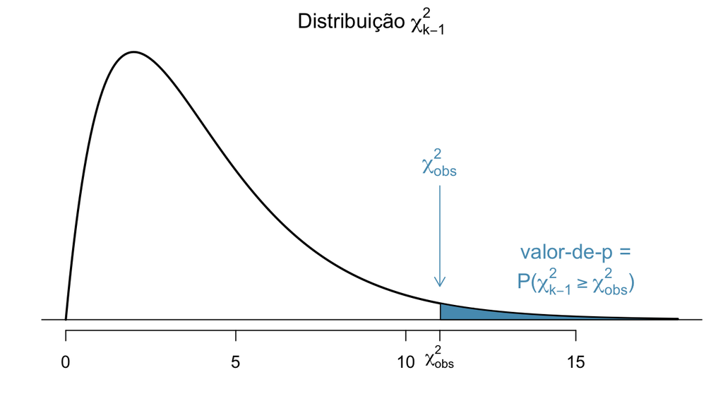

## Teste de Aderência - Procedimento

**Valor Crítico**: Para um nível de significância \(\alpha\), encontrar o valor crítico \(\chi^2_{crit}\) na tabela Chi-quadrado tal que \(P(\chi^2_{k-1} \geq \chi^2_{crit}) = \alpha.\)

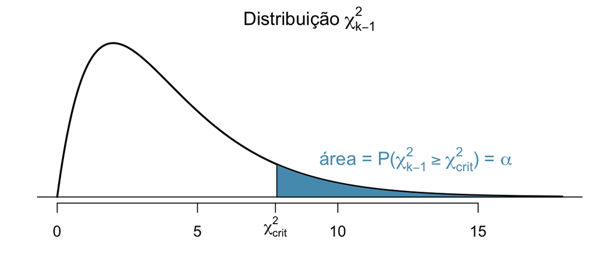

**Conclusão**: Rejeitamos \(H_0\) se

\[\mbox{valor-de-p} \leq \alpha \quad \mbox{ou} \quad \chi_{obs}^2 \geq \chi^2_{crit}\]

## Tabela da Distribuição Chi-Quadrado

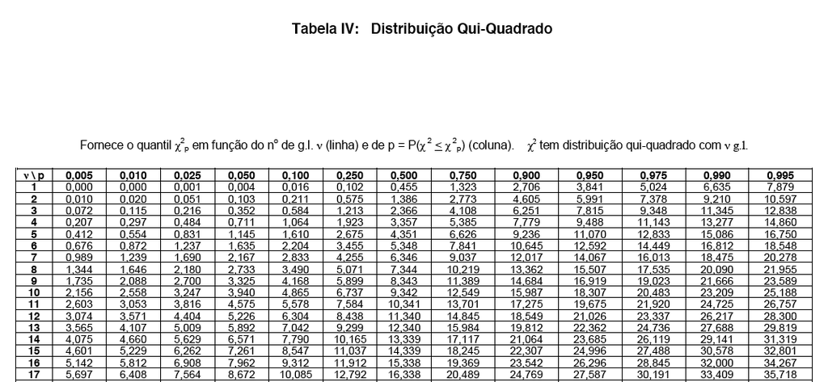

## Exemplo: Genética

Voltando no exemplo da Genética

**Hipóteses:** \[\begin{aligned} H_0: & \mbox{o modelo proposto é adequado} \\ H_a: & \mbox{o modelo proposto não é adequado} \end{aligned} \]

Que de forma equivalente, podem ser escritas como: \[\begin{aligned} H_0: & p_1=1/4, p_2=1/2 , p_3= 1/4 \\ H_a: & \mbox{ao menos umas das desigualdades não verifica} \end{aligned} \] sendo \(p_1=P(AA), p_2=P(Aa)\) e \(p_3=P(aa)\).

## Exemplo: Genética

A tabela seguinte apresenta os valores observados e esperados (calculados anteriormente).

| Genótipo | AA | Aa | aa | Total |
| --- | --- | --- | --- | --- |
| Frequência Observada | 26 | 45 | 29 | 100 |
| Frequência Esperada | 25 | 50 | 25 | 100 |

**Estatística do Teste**: \[ \begin{aligned} \chi^2_{obs} &= \sum_{i=1}^3 \frac{(O_i-E_i)^2}{E_i} = \frac{(26-25)^2}{25} + \frac{(45-50)^2}{50} + \frac{(29-25)^2}{25} \\ &= 0.04 + 0.5 + 0.64 = 1.18 \end{aligned} \]

## Exemplo: Genética

Sob \(H_0\), a estatística \(\chi^2 \sim \chi^2_2\). Veja que os graus de liberdade é o número de categorias menos 1. Então o valor-de-p é dado por:

\[\mbox{valor-de-p} = P(\chi^2_2 \geq \chi^2_{obs}) = P(\chi^2_2 \geq 1.18) = 0.554\]

Para um nível de significância \(\alpha=0.05\), olhando na Tabela Qui-Quadrado, o valor crítico é: \(\chi^2_{crit} = 5.991\)

**Conclusão:** Para \(\alpha = 0.05\), como valor-de-p\(= 0.554 > 0.05\), não rejeitamos a hipótese \(H_0\), isto é, essa população segue o modelo genético proposto.

Ou como \(\chi^2_{obs}=1.18 < 5.991 = \chi^2_{crit},\) não rejeitamos a hipótese \(H_0\).

## Exemplo: Genética

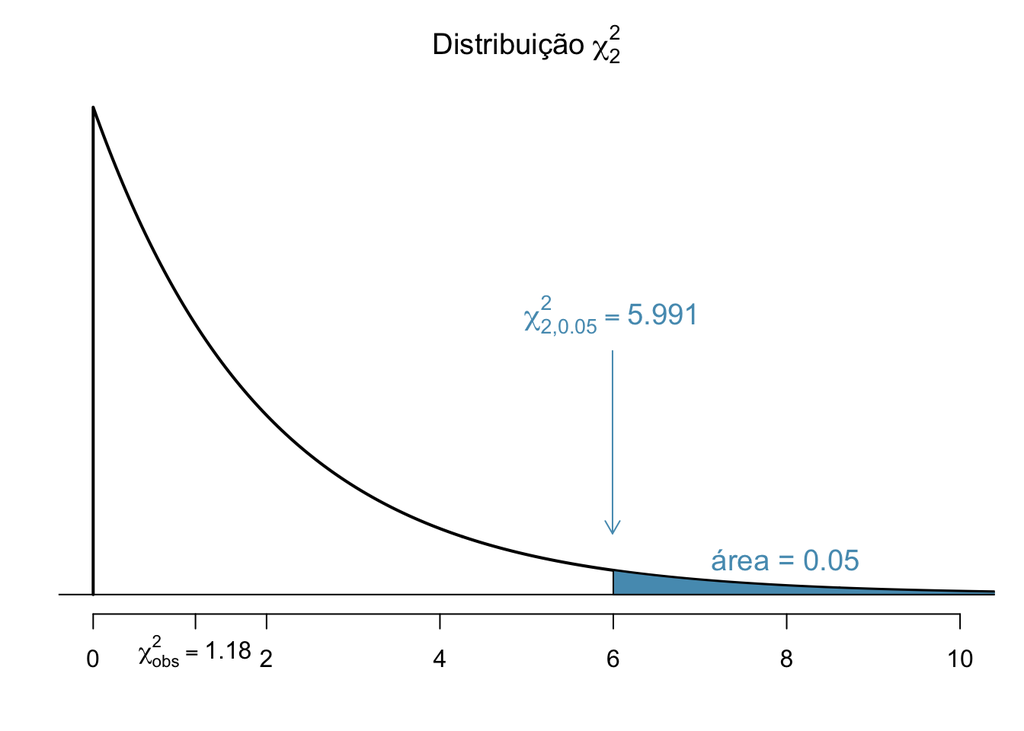

## Exemplo: Cores de Geladeira

Voltando aos dados do exemplo das cores da geladeira, cujas componentes têm frequências multinomiais, a hipótese nula especifica que as cinco cores são igualmente populares. Ou seja,  
\[\begin{aligned} H_0: & p_1=p_2= \ldots = p_k= 1/5 \\ H_a: & \mbox{existe pelo menos uma diferença} \end{aligned} \]

| Componente | marrom | creme | vermelho | azul | branco | total |
| --- | --- | --- | --- | --- | --- | --- |
| Frequência Observada | 88 | 65 | 52 | 40 | 55 | 300 |

Como as probabilidades das componentes na hipótese nula são todas iguais, as frequências esperadas também serão todas iguais, ou seja, \[E_i = n\times \frac{1}{5} = 300\times \frac{1}{5} = 60, \quad i=1,2,3,4,5.\]

## Exemplo: Cores de Geladeira

| Componente | marrom | creme | vermelho | azul | branco | total |
| --- | --- | --- | --- | --- | --- | --- |
| Frequência Observada | 88 | 65 | 52 | 40 | 55 | 300 |
| Frequência Esperada | 60 | 60 | 60 | 60 | 60 | 300 |
| \(\displaystyle \frac{(O-E)^2}{E}\) | 13.07 | 0.42 | 1.07 | 6.67 | 0.42 | 21.63 |

**Estatística do Teste:** \[\begin{aligned} \chi^2=\sum_{i=1}^5 \frac{(O_i-E_i)^2}{E_i} &= 13.07 + 0.42 + 1.07 + 6.67 + 0.42 \\ &= 21.63 \end{aligned} \]

## Exemplo: Cores de Geladeira

Olhando na tabela Qui-quadrado com 4 graus de liberdade, para \(\alpha=0.05\), o valor crítico é \(\chi^2_{crit} = \chi^2_{4, 0.05} = 9.488\).

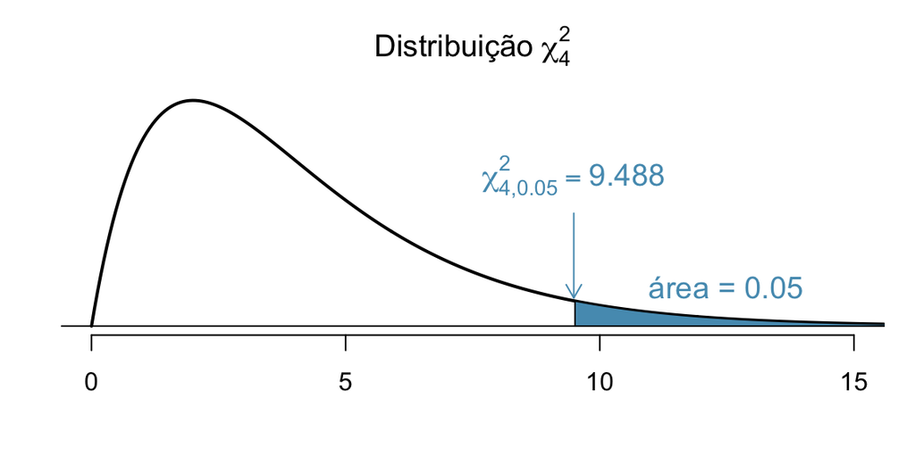

**Conclusão:** Para \(\alpha = 0.05\), como \(\chi^2_{obs}= 21.63 > 9.488 = \chi^2_{crit},\) rejeitamos a hipótese de que as cinco cores são igualmente populares.

## Exemplo: Tipo Sanguíneo

Entre os americanos, 41% tem sangue do tipo A, 9% tem sangue tipo B, 4% tipo AB e 46% tem sangue tipo O.

Em uma amostra aleatória de 200 pacientes americanos com câncer de estômago, 92 pacientes têm sangue do tipo A, 20 do tipo B, 4 do tipo AB e 84 do tipo O.

| Tipo | A | B | AB | O | total |
| --- | --- | --- | --- | --- | --- |
| Frequência Observada | 92 | 20 | 4 | 84 | 200 |

Essas frequências observadas trazem evidência contra a hipótese de que a distribuição do tipo sanguíneo dos pacientes é igual à distribuição dos tipos sanguíneos na população geral americana? Use nível de significância \(\alpha=0.05\).

## Exemplo: Tipo Sanguíneo

\[\begin{aligned} H_0: & p_1=0.41, p_2=0.09, p_3=0.04 , p_4=0.46 \\ H_a: & \mbox{existe pelo menos uma diferença} \end{aligned} \]

| Tipo | A | B | AB | O | total |
| --- | --- | --- | --- | --- | --- |
| Frequência Observada | 92 | 20 | 4 | 84 | 200 |
| Frequência Esperada | 82 | 18 | 8 | 92 | 200 |
| \(\displaystyle \frac{(O-E)^2}{E}\) | 1.22 | 0.22 | 2 | 0.7 | 4.14 |

**Estatística do Teste:** \(\displaystyle \chi^2=\sum_{i=1}^4 \frac{(O_i-E_i)^2}{E_i} = 4.14\)

## Exemplo: Tipo Sanguíneo

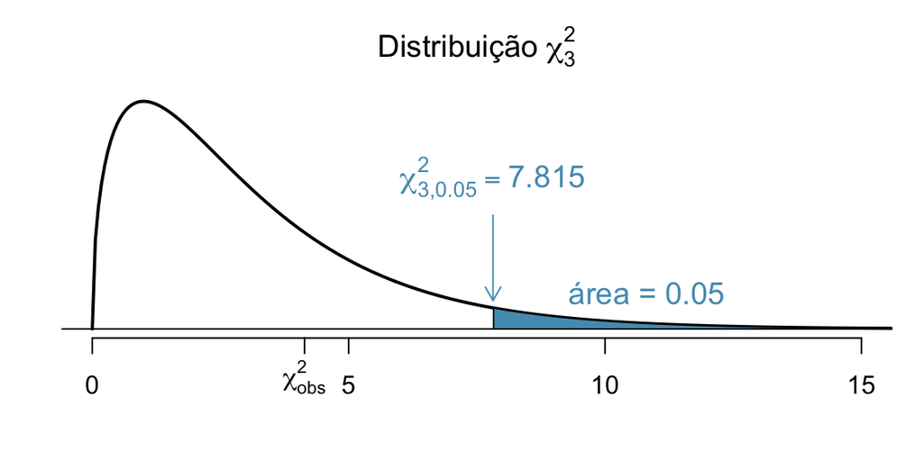

**Conclusão**: Como \(\chi^2_{obs} = 4.14 \leq 7.815= \chi^2_{3, 0.05}\), não temos evidência para rejeitar a hipótese nula.

Portanto, concluímos que não há discrepância significativa entre o que foi observado e a distribuição sanguínea da população americana.

## Exemplo: Ervilhas de Mendel

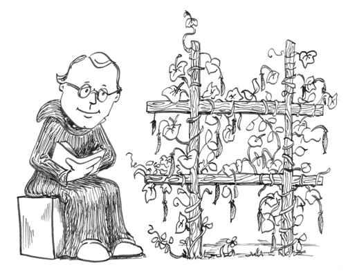

## Exemplo: Ervilhas de Mendel

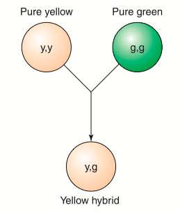

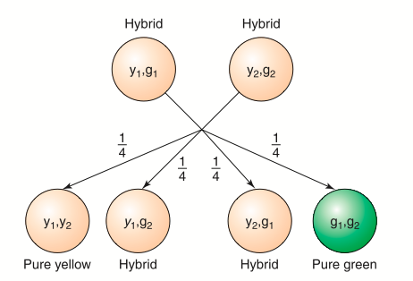

*Figura: (Esquerda) Cruzamento de ervilhas puramente amarelas e puramente verdes e (Direta) cruzamento de ervilhas híbridas (Direita)*

## Exemplo: Ervilhas de Mendel

Mendel fez o cruzamento de 8023 ervilhas híbridas e o resultado foram 6022 ervilhas amarelas e 2001 ervilhas verdes. Teoricamente, cada cruzamento deve resultar em ervilha amarela com probabilidade \(3/4\) e verde com probabilidade \(1/4\).

\[\begin{aligned} H_0: & p_1=3/4 \; \mbox{ e } \; p_2=1/4 \\ H_a: & \mbox{existe pelo menos uma diferença} \end{aligned} \]

| Tipo | Amarela | Verde | total |
| --- | --- | --- | --- |
| Frequência Observada | 6022 | 2001 | 8023 |
| Frequência Esperada | 6017.25 | 2005.75 | 8023 |
| \(\displaystyle \frac{(O-E)^2}{E}\) | 0.004 | 0.011 | 0.015 |

## Exemplo: Ervilhas de Mendel

**Estatística do Teste:** \(\displaystyle \chi^2=\sum_{i=1}^2 \frac{(O_i-E_i)^2}{E_i} = 0.015\)

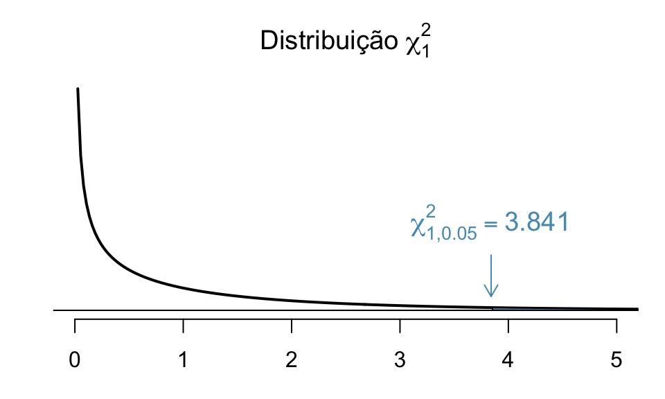

**Conclusão:** Como \(\chi^2_{obs} = 0.015 \leq 3.841= \chi^2_{1, 0.05}\), não temos evidência para rejeitar a hipótese nula. Concluímos que não há discrepância significativa entre o que foi observado e a hipótese nula.

## Leituras

- [Ross](http://www.sciencedirect.com/science/article/pii/B9780123743886000132): capítulo 13.
- [OpenIntro](https://www.openintro.org/stat/textbook.php): seção 6.3

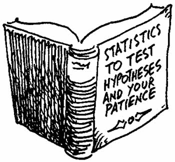

Slides produzidos pelos professores:

- Samara Kiihl
- Tatiana Benaglia
- Benilton Carvalho